# Thesis_Replication – User Guide

An R folder that reproduces the main results of the empirical chapters of *Imperfect Credibility at the Effective Lower Bound*

Author

Lloyd Allotey

Published

November 11, 2026

## 0 Overview

`Thesis_Replication` is the R folder behind the empirical chapters of the bachelor thesis *Imperfect Credibility at the Effective Lower Bound: A Behavioural Macroeconomic Analysis of Eurozone Inflation Expectations* (University of St. Gallen, November 2026). Two scripts do the work. `build_database.R` turns the raw downloads into a DuckDB database once. `main.R` reads that database, classifies the forecasters of the ECB Survey of Professional Forecasters (SPF), estimates the two behavioural parameters of the expectations block and evaluates both models against the SPF mean.

Research question of the thesis:

> To what extent does a time varying perceived inflation anchor improve the ability of the expectations block of a Behavioural New Keynesian model to explain euro area inflation expectations, particularly at the effective lower bound, and does any potential gain stem from the anchor itself or from agents switching between forecasting rules?

**Model A** is centred on the announced target of 2%. **Model B** is centred on the perceived anchor built from the 5y5y inflation-linked swap rate. **Model S**, centred on the mean SPF five-year-ahead forecast, is the robustness check.

With its default parameters `main.R` reproduces Tables 4.2, 5.3 to 5.7, 6.1 to 6.4 and J.1 and Figures 4.1 to 4.3, 5.1 to 5.4, J.1 and J.2. Not in the package are Table 4.3 and Figure 4.4 (capture ratios), Figures J.3 and J.4 and the dashed Wald curves of Figure 5.2.

## 1 Getting started

### 1.1 Requirements

- R 4.4 or 4.5 and RStudio
- An internet connection for the first start, when `renv` installs the packages
- No build tools. The packages come ready-built for Windows and macOS

### 1.2 Install

Extract the archive, open `Thesis_Replication.Rproj` in RStudio and run this once in the console:

```r
renv::restore(prompt = FALSE)
```

It installs the package versions of `renv.lock` into a project library and takes about a minute. On a Mac, unzip to Documents rather than Downloads.

### 1.3 First run

Open `main.R` and source it (the Source button, or Ctrl+Shift+S). The default run takes about two and a half minutes. Tables appear in the console, figures in the Plots pane. Nothing is written to disk.

### 1.4 Changing a parameter

Every parameter sits in Part I of `main.R` with its thesis value in a comment. Change a value and source the script again. Every table and figure follows. At the end the script lists the parameters that differ from the thesis and checks Table 5.6 against the thesis values.

### 1.5 Rebuild the database (optional)

```r
source("build_database.R")
```

The database ships ready, so this step is only needed if a raw file is replaced. The script reads the raw files in `data/raw/`, saves every cleaning step as its own table and prints the checks of the data chapter. It takes under a minute.

## 2 How the folder is organised

| File | Purpose |
| --- | --- |
| `main.R` | The analysis, one script read top to bottom |
| `build_database.R` | Builds `data/thesis.duckdb` from `data/raw/` |
| `data/raw/` | The raw downloads as obtained |
| `data/thesis.duckdb` | The database, 13 tables (Section 6) |
| `notebooks/user_guide.qmd` | This guide, rendered to `user_guide.html` |
| `renv.lock`, `renv/activate.R`, `.Rprofile` | The package versions |
| `README.md` | How to run it, in short |

`main.R` has ten parts. They are RStudio sections, so the document outline (Ctrl+Shift+O) jumps between them.

| Part | What it does | Main objects |
| --- | --- | --- |
| Set up | Loads the packages |  |
| I | Parameters | `anchor`, `score`, `delta`, the switches, `baseline`, `this_run` |
| II | Input checks |  |
| III | Loads the data, builds the centres, calibrates the constants | `panel`, `rounds`, `premium`, `models` |
| IV | Model functions | the functions of Section 4 |
| V | Classification, Table 4.2 | `classified`, `shares` |
| VI | Estimation, Table 5.3 | `fit`, `results` |
| VII | Evaluation, Tables 5.4, 5.6 and 5.7 |  |
| VIII | Side analyses, Tables 5.5 and 6.1 to 6.4, and Table J.1 | `real_time_biases` |
| IX | Comparison with the thesis | `changed`, `comparison` |
| X | Figures 4.1 to 4.3, 5.1 to 5.4, J.1 and J.2 |  |

Every table and figure stays in the workspace as an object. Its name starts with the thesis number and ends with a word for its content, for example `table_5_6_gain` or `fig_5_2_profiles`.

`build_database.R` has eleven parts in the same style, one per source and cleaning step.

## 3 Parameter reference (Part I of `main.R`)

Data inputs.

| Parameter | Thesis value | Meaning |
| --- | --- | --- |
| `DB_FILE` | `"data/thesis.duckdb"` | The database |
| `TABLE_PANEL`, `TABLE_ROUNDS` | `"estimation_panel"`, `"rounds"` | The two tables the script reads |

Four switches change the specification.

| Parameter | Thesis value | Meaning |
| --- | --- | --- |
| `anchor` | `"ILS"` | Centre of the second model. `"ILS"` gives Model B, `"LTSPF"` gives Model S |
| `score` | `"saturating"` | Performance score. `"saturating"` is Equation 5.2, `"msfe"` the squared error |
| `bias_statistic` | `"median"` | Statistic of the biases (Equation 5.5), `"median"` or `"mean"` |
| `bias_window` | `"complete"` | Rounds the biases are calibrated on. `"complete"` is the whole sample, `"pre ELB"` the rounds before `elb_from` |

Centres, sample and regimes.

| Parameter | Thesis value | Meaning |
| --- | --- | --- |
| `target` | `2` | Announced target, in %. It also sets the level of Model B’s centre |
| `first_round`, `last_round` | `"2004Q3"`, `"2026Q2"` | Estimation window, 88 rounds |
| `bench_from`, `bench_to` | `"2004Q3"`, `"2014Q2"` | Normalisation window of the perceived anchor (Equation 3.2) |
| `elb_from`, `elb_to` | `"2014Q3"`, `"2022Q2"` | ELB regime (Table 3.4) |
| `horizon` | `4` | Rounds between a forecast and its evaluation |

Calibrated constants. `NA` takes the value the thesis calibrates from the data. A number overrides that one constant and leaves the others unchanged, so the run shows its effect all else equal.

| Parameter | Default | Meaning |
| --- | --- | --- |
| `delta` | `NA` (0.2824) | Half width of the targeter band (Equation 4.3) |
| `E_star` | `NA` (3.11) | Threshold between ordinary and extreme errors (Equation 5.7) |
| `tau` | `NA` (0.399) | Scale of the saturating score (Equation 5.6) |
| `w` | `NA` (0.101) | Weight of the squared error (Equation 5.6) |
| `bias_up`, `bias_down` | `NA` per model | Hawk and dove bias. `NA` calibrates it (Equation 5.5), a number fixes it |
| `U_0` | `0` | Performance of every heuristic before the first evaluation |

Optimiser and side analyses.

| Parameter | Thesis value | Meaning |
| --- | --- | --- |
| `quick_mode` | `FALSE` | `FALSE` uses 300 starting values, `TRUE` 30. The package ships with `TRUE`, which gives the same estimates |
| `gamma_start_range`, `rho_start_range` | `c(0.01, 100)`, `c(0, 0.98)` | Ranges of the starting values |
| `run_feasibility` | `TRUE` | Table 5.5 |
| `run_anchors` | `TRUE` | Table 6.1 |
| `run_delta` | `TRUE` | Table 6.2 |
| `run_score` | `TRUE` | Table 6.3 |
| `run_biases` | `TRUE` | Table 6.4, the real-time rows of Table J.1 and Figures J.1 and J.2 |

## 4 Function reference (Part IV of `main.R`)

Three arguments recur. `model` is a model letter, `"A"`, `"B"` or `"S"`. `data` is the list returned by `prepare()`. `score_set` holds the settings of the score, made by `score_settings()`. Examples follow in Section 5.

### 4.1 Classification and data of a model

#### [1] **`classify(forecast, centre, delta)`**

- Assign each forecast to a type around its centre (Equation 4.1).

**Arguments**

- `forecast`, `centre : numeric` vectors of the same length.
- `delta : numeric`, half width of the targeter band.

**Returns**

- A character vector with `"hawk"`, `"targeter"` or `"dove"`.

#### [2] **`classify_panel(model, delta)`**

- Classify the whole panel around the centre of one model. The only place where forecasts are classified.

**Returns**

- The panel with the columns `model`, `regime`, `centre` and `type`.

#### [3] **`prepare(model, delta, b_up, b_down, statistic, window, same_rounds)`**

- Classify the forecasts around a centre, calibrate the two biases (Equation 5.5, done by `calibrate_biases()`) and collect the data of the scored rounds.

**Arguments**

- `model`, `delta` as above.
- `b_up`, `b_down : numeric or NA`, default the biases of Part I. `NA` calibrates the bias.
- `statistic`, `window : character`, default the two bias switches of Part I. `window = "real time"` gives real-time biases (Table 6.4).
- `same_rounds : logical`. `TRUE` scores constant biases on the rounds that real-time biases can use.

**Returns**

- A list with the counts per round, the centres, realised inflation, the SPF mean and the two biases.

#### [4] **`score_settings(tau, w, msfe = FALSE)`**

- Bundle the settings of the performance score.

**Returns**

- `list(tau, w, msfe)`. With `msfe = TRUE` the score is the squared error.

### 4.2 The expectations block

#### [5] **`probabilities(gamma, rho, data, score_set)`**

- The shares of the hawk, targeter and dove heuristic in every scored round (Equations 5.1 to 5.4).

The errors $e$ of the three heuristics against realised inflation are scored by

$$\psi(e) = \frac{e^2}{e^2 + \tau^2} + w\,e^2,$$

accumulated into the performance $U_t = \rho\,U_{t-1} - (1 - \rho)\,\psi(e_t)$ and turned into shares by the multinomial logit.

**Arguments**

- `gamma`, `rho : numeric`, intensity of choice and memory.

**Returns**

- A matrix, one row per scored round, three columns that sum to one.

#### [6] **`minus_loglik(par, data, score_set)`**

- Minus the multinomial log-likelihood (Equation 5.8), the objective of the optimiser.

**Arguments**

- `par : numeric(2)`, `c(gamma, rho)`.

**Returns**

- One number, 1e12 outside $\gamma$ in [0, 1000] and $\rho$ in [0, 0.999).

### 4.3 Estimation

#### [7] **`starting_values(n_gamma, n_rho)`**

- The starting grid, log-spaced $\gamma$ times evenly spaced $\rho$.

**Returns**

- A data frame with the columns `gamma` and `rho`.

#### [8] **`estimate(data, score_set, starts)`**

- Nelder-Mead from every starting value, each search restarted once.

**Returns**

- A list with `gamma`, `rho`, `loglik` and `searches`, the end point of every search.

#### [9] **`dispersion(data, prob)`**

- The dispersion factor $\hat\varphi$ (Equation 5.10).

**Returns**

- One number, 15.35 for Model A and 15.36 for Model B.

#### [10] **`standard_errors(gamma, rho, data, score_set, phi)`**

- Standard errors from the Hessian, multiplied by $\hat\varphi$ (Equations 5.11 and 5.12).

**Returns**

- `list(se, correlation)`. Both are `NA` with a warning when the estimate lies at a bound or the Hessian cannot be inverted.

#### [11] **`fit_model(model, score_set, starts, delta_used = delta, statistic, window, same_rounds)`**

- One complete fit of a model. Calls the functions above and forms the aggregate expectation (Equation 5.13) and its error against the SPF mean (Equation 5.14). `statistic`, `window` and `same_rounds` choose the biases as in `prepare()`.

**Returns**

- A list with everything from `prepare()` and `estimate()`, plus `prob`, `phi`, `se`, `correlation` and `results`, a table with one row per scored round. The fits of the run live in `fit$A` and `fit$B` (or `fit$S`).

### 4.4 Evaluation helpers

#### [12] **`rmsfe(error)`, `mafe(error)`, `msfe(error)`**

- Root mean squared, mean absolute and mean squared forecast error (Equation 5.14).

#### [13] **`with_full_sample(rows)`**

- Repeat every row under the regime `"Full sample"`, so that a `group_by(regime)` also gives the full-sample line.

#### [14] **`summarise_fit(model_fit, variation)`**

- One row in the layout of the Chapter 6 tables.

#### [15] **`both_models(variation, score_set, delta_used = delta)`**

- Fit Model A and the second model under one setting from 30 starting values and return their two rows.

#### [16] **`show_variations(rows)`**

- Print such rows in the thesis layout, each loss as “A / B”. `layout_variations()` returns the same table without printing it.

Small helpers format numbers (`three()`, `two()`, `pct()`, `signed()`, `wald()`), check the parameters (`is_number()`, `is_number_or_na()`, `is_round()`), date the regimes (`regime_of()`), pick one element from both fits (`from_fits()`) and name a fit in a warning (`fit_label()`).

## 5 Outputs and examples

The chunk below runs `main.R` with its defaults. Each output is then shown as the script produces it, followed by a variant that calls the functions of Section 4 directly.

```r
source("main.R")
```

### 5.1 The sample and the constants

```r
knitr::kable(
  rounds |>
    group_by(regime) |>
    summarise(rounds = n(), first = min(round), last = max(round),
              `mean centre A` = mean(centre_A), `mean centre B` = mean(centre_B)) |>
    arrange(first),
  digits = 2)
```

Table 1: Rounds by regime and the mean of the two centres.

| regime | rounds | first | last | mean centre A | mean centre B |
| --- | --- | --- | --- | --- | --- |
| Pre ELB | 40 | 2004Q3 | 2014Q2 | 2 | 2.00 |
| ELB | 32 | 2014Q3 | 2022Q2 | 2 | 1.24 |
| Post ELB | 16 | 2022Q3 | 2026Q2 | 2 | 1.90 |

```r
cat("Premium of the swap rate:", round(premium, 4), "\n")
```

```
Premium of the swap rate: 0.3452
```

```r
knitr::kable(data.frame(used      = c(delta, E_star, tau, w),
                        from_data = from_data[c("delta", "E_star", "tau", "w")],
                        row.names = c("delta", "E_star", "tau", "w")), digits = 5)
```

Table 2: The constants in use and the values implied by the data (4’001 forecast errors).

|  | used | from_data |
| --- | --- | --- |
| delta | 0.28242 | 0.28242 |
| E_star | 3.11346 | 3.11346 |
| tau | 0.39941 | 0.39941 |
| w | 0.10149 | 0.10149 |

### Output 1: Classification, Table 4.2

`classified` holds every forecast with its type, `shares` the three shares per round and model.

**Default call:**

```r
knitr::kable(table_4_2_shares, digits = 2)
```

Table 3: Table 4.2: mean targeter share by regime, in %.

| regime | rounds | targeter_share_second | targeter_share_A | difference_pp |
| --- | --- | --- | --- | --- |
| Full sample | 88 | 47.03 | 31.71 | 15.32 |
| Pre ELB | 40 | 51.50 | 45.12 | 6.38 |
| ELB | 32 | 44.87 | 9.56 | 35.32 |
| Post ELB | 16 | 40.16 | 42.50 | -2.34 |

**Variant** (a band twice as wide):

```r
wide <- prepare("A", delta = 2 * delta)
colSums(wide$counts)                      # hawks, targeters, doves over the 84 scored rounds
```

```
    hawk targeter     dove
     302     2343     1308
```

```r
c(hawk_bias = wide$b_up, dove_bias = wide$b_down)
```

```
hawk_bias dove_bias
      1.1       0.8
```

### Output 2: Estimates, Table 5.3

`fit$A` and `fit$B` are the two fits of the run.

**Default call:**

```r
knitr::kable(table_5_3_estimates)
```

Table 4: Table 5.3: overdispersion, standard errors and confidence intervals.

|  | Model A | Model B |
| --- | --- | --- |
| Intensity of choice, gamma | 3.056 | 2.271 |
| Memory, rho | 0.611 | 0.625 |
| Correlation | 0.47 | 0.55 |
| Dispersion factor, phi | 15.35 | 15.36 |
| Se(gamma), Se(rho) | 0.347, 0.069 | 0.396, 0.098 |
| Wald interval, gamma | [2.376, 3.737] | [1.495, 3.047] |
| Wald interval, rho | [0.475, 0.746] | [0.432, 0.817] |
| Log-likelihood | -3265.99 | -3908.93 |

**Variant** (Model B under the -MSFE score, 30 starting values):

```r
fit_B_msfe <- fit_model("B", score_settings(tau, w, msfe = TRUE), starting_values(6, 5))
knitr::kable(summarise_fit(fit_B_msfe, "-MSFE"), digits = c(NA, NA, rep(3, 9), 0))
```

| variation | model | gamma | rho | b_up | b_down | rmsfe_full | rmsfe_elb | mafe_full | mafe_elb | centre_rmsfe_elb | gain_elb |
| --- | --- | --- | --- | --- | --- | --- | --- | --- | --- | --- | --- |
| -MSFE | B | 0.381 | 0.197 | 0.487 | 0.544 | 0.451 | 0.285 | 0.303 | 0.244 | 0.323 | 12 |

### Output 3: Evaluation, Tables 5.4, 5.6 and 5.7

`results` holds one row per scored round and model. Table 5.6 splits the fit into the centre alone and what switching adds. Table 5.7 starts both models from the announced target alone and adds the location gain.

**Default call:**

```r
knitr::kable(table_5_4_errors, digits = 3)
```

Table 5: Table 5.4: model expectations against the mean SPF forecast, by regime.

| regime | rounds | model | MSFE | RMSFE | MAFE |
| --- | --- | --- | --- | --- | --- |
| Full sample | 84 | A | 0.242 | 0.492 | 0.380 |
| Full sample | 84 | B | 0.224 | 0.473 | 0.302 |
| Full sample | 84 | A-B | 0.018 | 0.019 | 0.078 |
| Pre ELB | 36 | A | 0.188 | 0.433 | 0.351 |
| Pre ELB | 36 | B | 0.163 | 0.403 | 0.285 |
| Pre ELB | 36 | A-B | 0.025 | 0.030 | 0.066 |
| ELB | 32 | A | 0.194 | 0.441 | 0.378 |
| ELB | 32 | B | 0.088 | 0.297 | 0.247 |
| ELB | 32 | A-B | 0.106 | 0.144 | 0.131 |
| Post ELB | 16 | A | 0.461 | 0.679 | 0.451 |
| Post ELB | 16 | B | 0.634 | 0.796 | 0.450 |
| Post ELB | 16 | A-B | -0.173 | -0.117 | 0.001 |

```r
knitr::kable(table_5_6_gain, digits = c(NA, NA, 3, 3, 3, 0))
```

Table 6: Table 5.6: RMSFE of the centre alone and of the complete model, in pp, and the switching gain.

| regime | model | centre_only | complete | gain | gain_pct |
| --- | --- | --- | --- | --- | --- |
| Full sample | A | 0.667 | 0.492 | 0.175 | 26 |
| Full sample | B | 0.555 | 0.473 | 0.082 | 15 |
| Pre ELB | A | 0.402 | 0.433 | -0.031 | -8 |
| Pre ELB | B | 0.451 | 0.403 | 0.047 | 11 |
| ELB | A | 0.730 | 0.441 | 0.289 | 40 |
| ELB | B | 0.323 | 0.297 | 0.026 | 8 |
| Post ELB | A | 0.951 | 0.679 | 0.272 | 29 |
| Post ELB | B | 0.975 | 0.796 | 0.179 | 18 |

```r
knitr::kable(table_5_7_location, digits = c(NA, NA, rep(3, 6), 0))
```

Table 7: Table 5.7: RMSFE of the target alone, of the centre alone and of the complete model, in pp, with the location gain, the switching gain and the total gain.

| regime | model | target_alone | centre_only | complete | location_gain | switching_gain | total_gain | total_gain_pct |
| --- | --- | --- | --- | --- | --- | --- | --- | --- |
| Full sample | A | 0.667 | 0.667 | 0.492 | 0.000 | 0.175 | 0.175 | 26 |
| Full sample | B | 0.667 | 0.555 | 0.473 | 0.112 | 0.082 | 0.193 | 29 |
| Pre ELB | A | 0.402 | 0.402 | 0.433 | 0.000 | -0.031 | -0.031 | -8 |
| Pre ELB | B | 0.402 | 0.451 | 0.403 | -0.049 | 0.047 | -0.001 | 0 |
| ELB | A | 0.730 | 0.730 | 0.441 | 0.000 | 0.289 | 0.289 | 40 |
| ELB | B | 0.730 | 0.323 | 0.297 | 0.407 | 0.026 | 0.433 | 59 |
| Post ELB | A | 0.951 | 0.951 | 0.679 | 0.000 | 0.272 | 0.272 | 29 |
| Post ELB | B | 0.951 | 0.975 | 0.796 | -0.024 | 0.179 | 0.155 | 16 |

**Variant** (the shares for a chosen pair, $\gamma$ = 1 and $\rho$ = 0.9, in Model A):

```r
shares_chosen <- probabilities(gamma = 1, rho = 0.9, fit$A, base_score)
knitr::kable(data.frame(round = fit$A$round, round(shares_chosen, 3))[1:5, ])
```

| round | X1 | X2 | X3 |
| --- | --- | --- | --- |
| 2005Q3 | 0.323 | 0.351 | 0.326 |
| 2005Q4 | 0.343 | 0.345 | 0.313 |
| 2006Q1 | 0.339 | 0.356 | 0.305 |
| 2006Q2 | 0.336 | 0.366 | 0.298 |
| 2006Q3 | 0.349 | 0.361 | 0.290 |

### Output 4: Side analyses, Tables 5.5 and 6.1 to 6.4, Table J.1

Each table exists when its switch is `TRUE`. Table J.1 is printed in every run and has its real-time rows when `run_biases` is `TRUE`.

**Default call:**

```r
knitr::kable(table_5_5_feasibility, digits = 3)
```

Table 8: Table 5.5: rounds in which the SPF mean lies outside the attainable range, and their mean distance to it.

| regime | rounds | outside_A | below_A | above_A | distance_A | outside_B | below_B | above_B | distance_B |
| --- | --- | --- | --- | --- | --- | --- | --- | --- | --- |
| Full sample | 84 | 31 | 25 | 6 | 0.309 | 15 | 8 | 7 | 0.520 |
| Pre ELB | 36 | 6 | 6 | 0 | 0.127 | 7 | 7 | 0 | 0.350 |
| ELB | 32 | 20 | 19 | 1 | 0.240 | 2 | 1 | 1 | 0.133 |
| Post ELB | 16 | 5 | 0 | 5 | 0.806 | 6 | 0 | 6 | 0.848 |

```r
knitr::kable(table_6_1_anchors)
```

Table 9: Table 6.1: Models A, B and S.

| model | gamma | rho | biases | rmsfe_full | rmsfe_elb | mafe_full | mafe_elb | centre_rmsfe_elb | gain_elb |
| --- | --- | --- | --- | --- | --- | --- | --- | --- | --- |
| A | 3.056 | 0.611 | 0.700 / 0.600 | 0.492 | 0.441 | 0.380 | 0.378 | 0.730 | +40% |
| B | 2.271 | 0.625 | 0.487 / 0.544 | 0.473 | 0.297 | 0.302 | 0.247 | 0.323 | +8% |
| S | 2.805 | 0.588 | 0.594 / 0.531 | 0.431 | 0.348 | 0.314 | 0.280 | 0.537 | +35% |

```r
knitr::kable(table_6_2_delta |>
               select(variation, model, gamma, rho, b_up, b_down, rmsfe_full, rmsfe_elb,
                      mafe_full, mafe_elb, gain_elb),
             digits = c(NA, NA, rep(3, 8), 0))
```

Table 10: Table 6.2: sensitivity to the tolerance parameter.

| variation | model | gamma | rho | b_up | b_down | rmsfe_full | rmsfe_elb | mafe_full | mafe_elb | gain_elb |
| --- | --- | --- | --- | --- | --- | --- | --- | --- | --- | --- |
| Baseline | A | 3.056 | 0.611 | 0.700 | 0.600 | 0.492 | 0.441 | 0.380 | 0.378 | 40 |
| Baseline | B | 2.271 | 0.625 | 0.487 | 0.544 | 0.473 | 0.297 | 0.302 | 0.247 | 8 |
| delta = 0.1412 (-50%) | A | 3.043 | 0.637 | 0.500 | 0.550 | 0.514 | 0.485 | 0.391 | 0.421 | 34 |
| delta = 0.1412 (-50%) | B | 2.511 | 0.624 | 0.374 | 0.419 | 0.491 | 0.297 | 0.310 | 0.250 | 8 |
| delta = 0.2118 (-25%) | A | 3.046 | 0.615 | 0.700 | 0.600 | 0.493 | 0.442 | 0.381 | 0.378 | 39 |
| delta = 0.2118 (-25%) | B | 2.329 | 0.627 | 0.425 | 0.474 | 0.483 | 0.296 | 0.306 | 0.249 | 8 |
| delta = 0.3530 (+25%) | A | 2.950 | 0.590 | 0.800 | 0.700 | 0.466 | 0.380 | 0.355 | 0.321 | 48 |
| delta = 0.3530 (+25%) | B | 2.251 | 0.637 | 0.574 | 0.603 | 0.464 | 0.295 | 0.299 | 0.242 | 9 |
| delta = 0.4236 (+50%) | A | 2.992 | 0.596 | 0.900 | 0.700 | 0.463 | 0.373 | 0.353 | 0.313 | 49 |
| delta = 0.4236 (+50%) | B | 2.081 | 0.646 | 0.656 | 0.680 | 0.460 | 0.298 | 0.300 | 0.243 | 8 |

```r
knitr::kable(table_6_3_score |>
               select(variation, model, gamma, rho, rmsfe_full, rmsfe_elb, mafe_full,
                      mafe_elb, gain_elb),
             digits = c(NA, NA, rep(3, 6), 0))
```

Table 11: Table 6.3: sensitivity of the performance score.

| variation | model | gamma | rho | rmsfe_full | rmsfe_elb | mafe_full | mafe_elb | gain_elb |
| --- | --- | --- | --- | --- | --- | --- | --- | --- |
| Baseline | A | 3.056 | 0.611 | 0.492 | 0.441 | 0.380 | 0.378 | 40 |
| Baseline | B | 2.271 | 0.625 | 0.473 | 0.297 | 0.302 | 0.247 | 8 |
| -MSFE | A | 0.676 | 0.501 | 0.457 | 0.440 | 0.368 | 0.415 | 40 |
| -MSFE | B | 0.381 | 0.197 | 0.451 | 0.285 | 0.303 | 0.244 | 12 |
| tau = 0.1997 (-50%) | A | 3.105 | 0.610 | 0.503 | 0.462 | 0.391 | 0.396 | 37 |
| tau = 0.1997 (-50%) | B | 2.501 | 0.649 | 0.471 | 0.299 | 0.300 | 0.251 | 7 |
| tau = 0.2996 (-25%) | A | 3.022 | 0.612 | 0.498 | 0.453 | 0.386 | 0.388 | 38 |
| tau = 0.2996 (-25%) | B | 2.365 | 0.643 | 0.472 | 0.297 | 0.301 | 0.248 | 8 |
| tau = 0.4993 (+25%) | A | 3.142 | 0.608 | 0.486 | 0.428 | 0.375 | 0.368 | 41 |
| tau = 0.4993 (+25%) | B | 2.200 | 0.600 | 0.474 | 0.297 | 0.303 | 0.247 | 8 |
| tau = 0.5991 (+50%) | A | 3.250 | 0.605 | 0.480 | 0.415 | 0.370 | 0.358 | 43 |
| tau = 0.5991 (+50%) | B | 2.150 | 0.572 | 0.474 | 0.298 | 0.304 | 0.247 | 8 |
| tau = 0.7988 (+100%) | A | 3.488 | 0.599 | 0.470 | 0.396 | 0.362 | 0.346 | 46 |
| tau = 0.7988 (+100%) | B | 2.111 | 0.508 | 0.474 | 0.300 | 0.306 | 0.248 | 7 |
| w = 0.0000 (-100%) | A | 3.900 | 0.698 | 0.625 | 0.579 | 0.462 | 0.479 | 21 |
| w = 0.0000 (-100%) | B | 3.353 | 0.745 | 0.541 | 0.312 | 0.336 | 0.261 | 3 |
| w = 0.0507 (-50%) | A | 3.749 | 0.657 | 0.527 | 0.477 | 0.402 | 0.400 | 35 |
| w = 0.0507 (-50%) | B | 3.017 | 0.697 | 0.492 | 0.301 | 0.311 | 0.251 | 7 |
| w = 0.0761 (-25%) | A | 3.380 | 0.633 | 0.505 | 0.455 | 0.388 | 0.386 | 38 |
| w = 0.0761 (-25%) | B | 2.606 | 0.661 | 0.481 | 0.298 | 0.306 | 0.249 | 8 |
| w = 0.1269 (+25%) | A | 2.785 | 0.592 | 0.484 | 0.432 | 0.375 | 0.372 | 41 |
| w = 0.1269 (+25%) | B | 2.005 | 0.590 | 0.468 | 0.295 | 0.300 | 0.246 | 8 |
| w = 0.1522 (+50%) | A | 2.557 | 0.576 | 0.478 | 0.425 | 0.371 | 0.370 | 42 |
| w = 0.1522 (+50%) | B | 1.792 | 0.558 | 0.465 | 0.295 | 0.298 | 0.244 | 9 |
| w = 0.2030 (+100%) | A | 2.196 | 0.552 | 0.470 | 0.418 | 0.367 | 0.368 | 43 |
| w = 0.2030 (+100%) | B | 1.476 | 0.501 | 0.460 | 0.293 | 0.297 | 0.242 | 9 |

```r
knitr::kable(table_6_4_biases |>
               select(rounds, variation, model, gamma, rho, rmsfe_full, rmsfe_elb, mafe_full,
                      mafe_elb, gain_elb),
             digits = c(0, NA, NA, rep(3, 6), 0))
```

Table 12: Table 6.4: sensitivity to the calibration of the biases. The column rounds gives the scored rounds of each fit.

| rounds | variation | model | gamma | rho | rmsfe_full | rmsfe_elb | mafe_full | mafe_elb | gain_elb |
| --- | --- | --- | --- | --- | --- | --- | --- | --- | --- |
| 84 | Baseline, medians, complete sample | A | 3.056 | 0.611 | 0.492 | 0.441 | 0.380 | 0.378 | 40 |
| 84 | Baseline, medians, complete sample | B | 2.271 | 0.625 | 0.473 | 0.297 | 0.302 | 0.247 | 8 |
| 84 | Means, complete sample | A | 3.054 | 0.630 | 0.460 | 0.370 | 0.358 | 0.307 | 49 |
| 84 | Means, complete sample | B | 1.667 | 0.578 | 0.457 | 0.286 | 0.301 | 0.234 | 11 |
| 84 | Medians, pre ELB sample | A | 3.836 | 0.628 | 0.516 | 0.486 | 0.387 | 0.422 | 33 |
| 84 | Medians, pre ELB sample | B | 2.360 | 0.608 | 0.480 | 0.308 | 0.303 | 0.257 | 5 |
| 80 | Baseline, same rounds | A | 2.998 | 0.577 | 0.499 | 0.445 | 0.386 | 0.383 | 39 |
| 80 | Baseline, same rounds | B | 2.257 | 0.616 | 0.484 | 0.297 | 0.313 | 0.247 | 8 |
| 80 | Medians, real time | A | 4.085 | 0.619 | 0.495 | 0.425 | 0.364 | 0.352 | 42 |
| 80 | Medians, real time | B | 2.467 | 0.621 | 0.484 | 0.304 | 0.311 | 0.254 | 6 |
| 80 | Means, real time | A | 3.573 | 0.611 | 0.459 | 0.388 | 0.347 | 0.320 | 47 |
| 80 | Means, real time | B | 2.067 | 0.569 | 0.461 | 0.314 | 0.297 | 0.260 | 3 |

```r
knitr::kable(table_j_1_biases, digits = 3)
```

Table 13: Table J.1: the hawk and dove bias of both models under each calibration. Real-time biases are averaged over the rounds of each regime.

| variation | regime | hawk_A | dove_A | hawk_B | dove_B |
| --- | --- | --- | --- | --- | --- |
| Baseline, medians, complete sample | constant | 0.700 | 0.600 | 0.487 | 0.544 |
| Means, complete sample | constant | 1.031 | 0.689 | 0.754 | 0.653 |
| Medians, pre ELB sample | constant | 0.400 | 0.500 | 0.407 | 0.556 |
| Medians, real time | Pre ELB | 0.382 | 0.453 | 0.393 | 0.539 |
| Medians, real time | ELB | 0.400 | 0.591 | 0.410 | 0.552 |
| Medians, real time | Post ELB | 0.667 | 0.600 | 0.487 | 0.545 |
| Means, real time | Pre ELB | 0.433 | 0.526 | 0.437 | 0.622 |
| Means, real time | ELB | 0.470 | 0.681 | 0.463 | 0.661 |
| Means, real time | Post ELB | 1.045 | 0.695 | 0.751 | 0.655 |

**Variant** (a wider band under the -MSFE score):

```r
knitr::kable(both_models("-MSFE, delta +50%", score_settings(tau, w, msfe = TRUE),
                         delta_used = 1.5 * delta) |>
               select(variation, model, gamma, rho, rmsfe_elb, gain_elb),
             digits = c(NA, NA, 3, 3, 3, 0))
```

| variation | model | gamma | rho | rmsfe_elb | gain_elb |
| --- | --- | --- | --- | --- | --- |
| -MSFE, delta +50% | A | 0.528 | 0.434 | 0.422 | 42 |
| -MSFE, delta +50% | B | 0.307 | 0.226 | 0.283 | 12 |

### Output 5: Figures

The figures are objects, so `fig_5_3_expectations` in the console draws Figure 5.3 again.

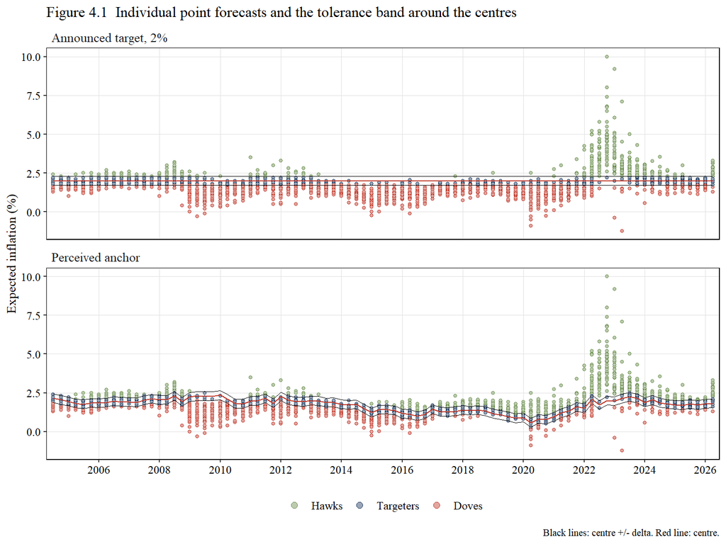

Figure 1: Figure 4.1: every point forecast and the tolerance band around the two centres. Black lines: centre +/- delta. Red line: the centre.

```r
fig_4_1_forecasts
```

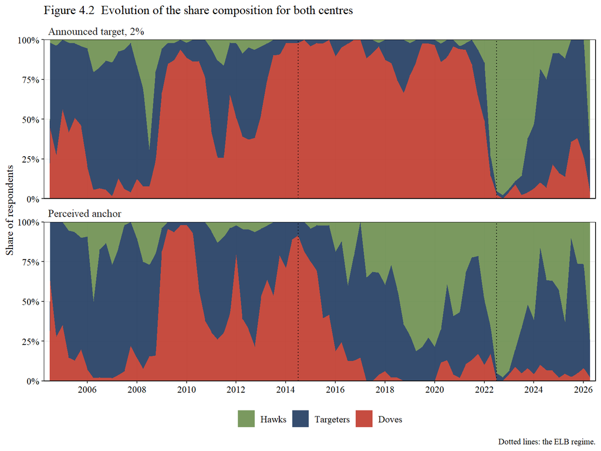

Figure 2: Figure 4.2: the share composition under both centres. Dotted lines: the ELB regime.

```r
fig_4_2_shares
```

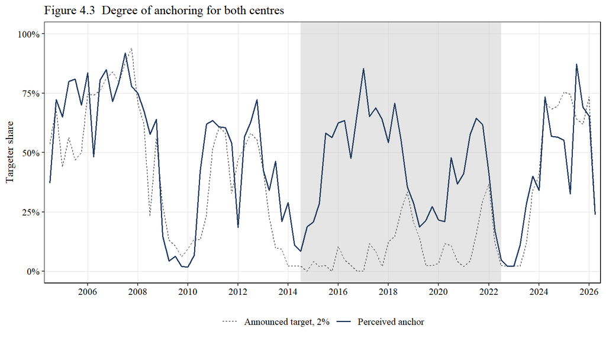

Figure 3: Figure 4.3: the targeter share around both centres. Shaded: the ELB regime.

```r
fig_4_3_targeters
```

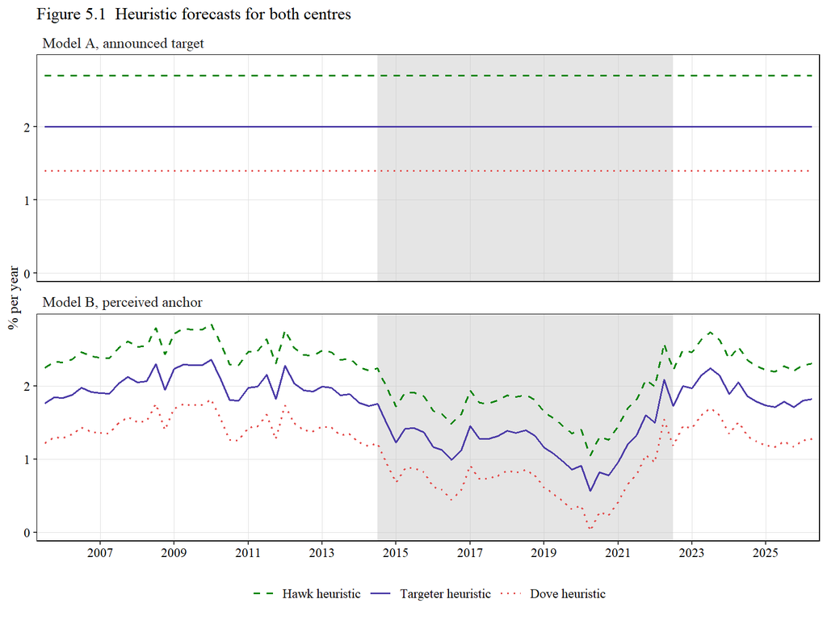

Figure 4: Figure 5.1: the three heuristics of each model.

```r
fig_5_1_heuristics
```

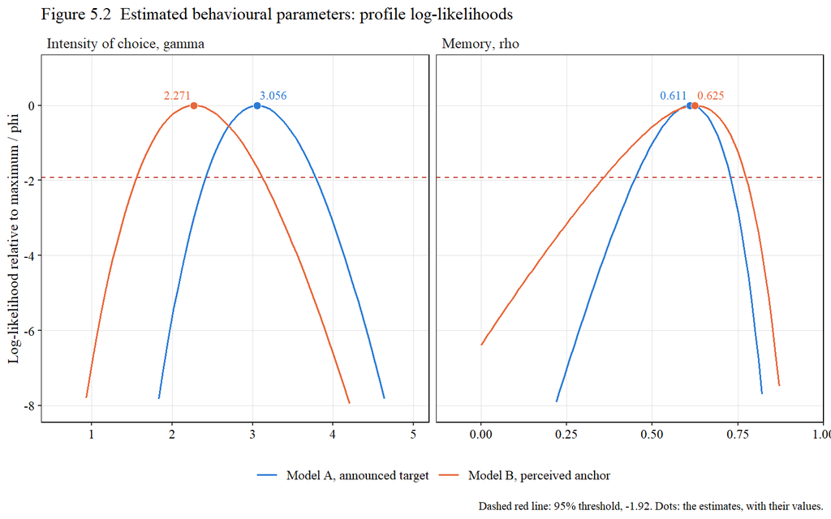

Figure 5: Figure 5.2: profile log-likelihood of each parameter. Values above -1.92 lie inside the 95% interval. The dots are the estimates. The thesis figure also shows dashed Wald curves, which are not drawn here.

```r
fig_5_2_profiles
```

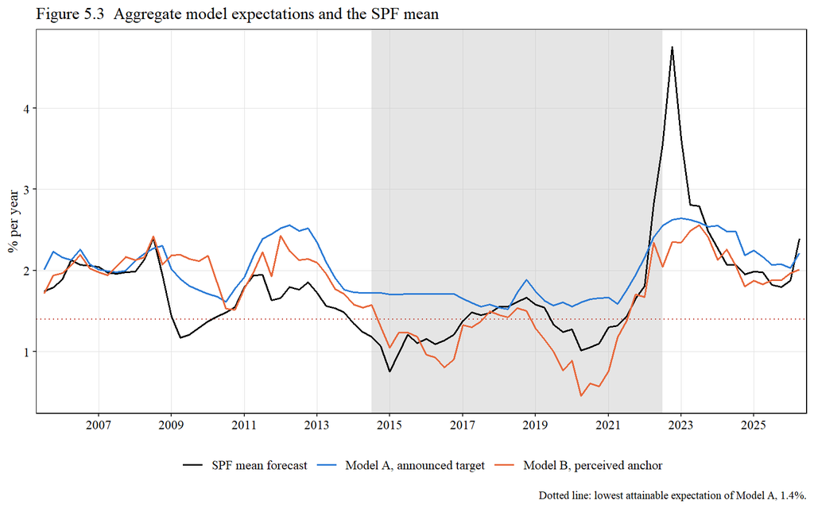

Figure 6: Figure 5.3: the aggregate expectation of each model and the SPF mean. Dotted: the lowest expectation Model A can produce.

```r
fig_5_3_expectations
```

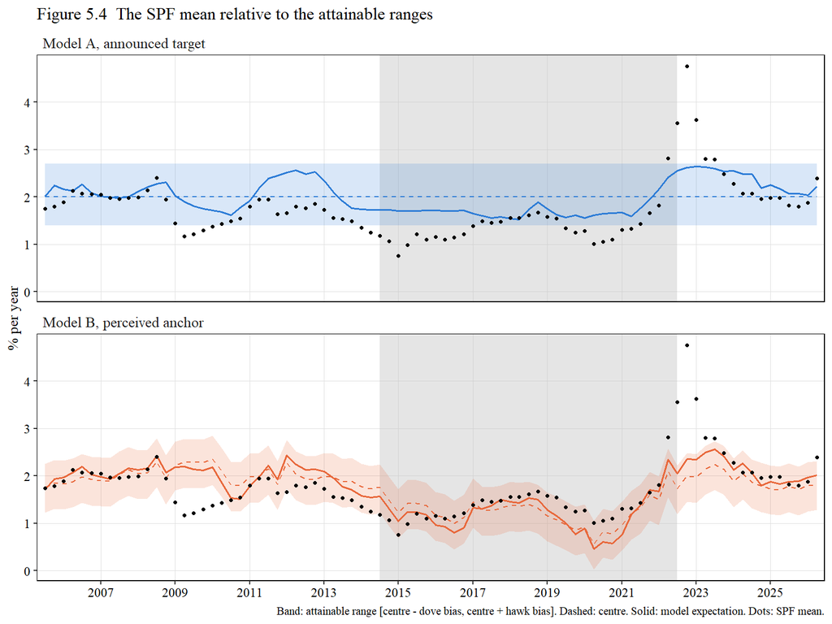

Figure 7: Figure 5.4: the SPF mean (dots) relative to the attainable range of each model (band), with the centre (dashed) and the model expectation (solid).

```r
fig_5_4_range
```

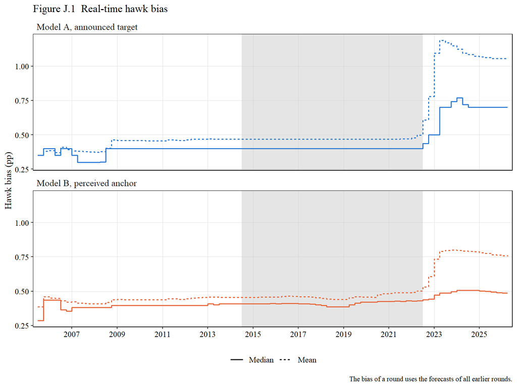

Figure 8: Figure J.1: the real-time hawk bias of both models. Solid: median. Dashed: mean. Shaded: the ELB regime.

```r
fig_j_1_hawk_bias
```

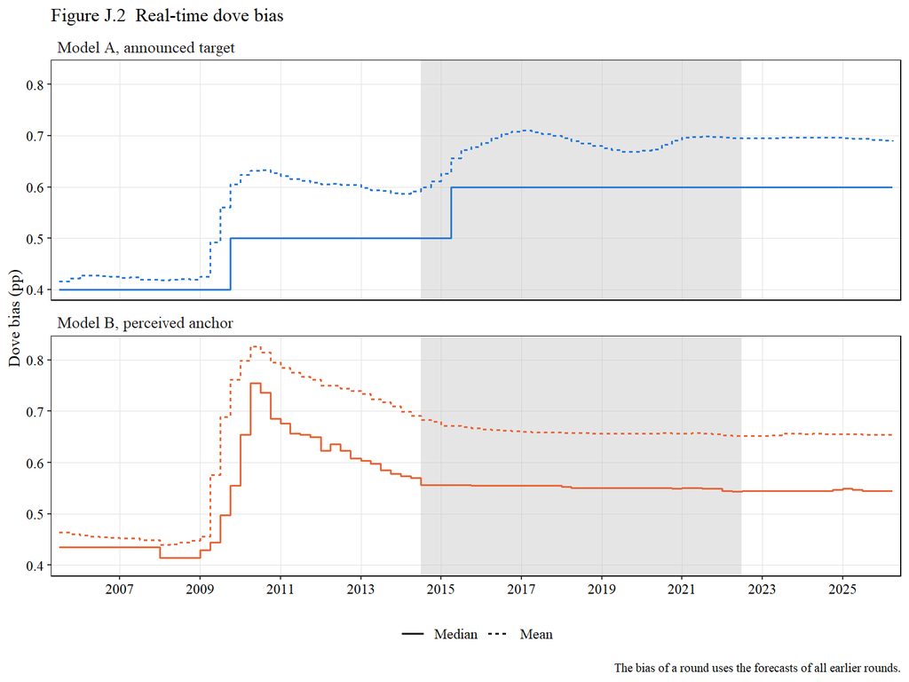

Figure 9: Figure J.2: the real-time dove bias of both models. Solid: median. Dashed: mean. Shaded: the ELB regime.

```r
fig_j_2_dove_bias
```

### Output 6: Comparison with the thesis baseline

```r
if (length(changed) == 0) cat("No parameter differs from the thesis baseline.\n") else print(changed)
```

```
[1] "quick_mode"
```

```r
knitr::kable(comparison)
```

Table 14: Table 5.6 of this run next to the thesis values. The last column marks a match to three decimals.

| regime | model | centre_only | thesis_centre | complete | thesis_complete | gain_pct | thesis_gain | match |
| --- | --- | --- | --- | --- | --- | --- | --- | --- |
| Full sample | A | 0.667 | 0.667 | 0.492 | 0.492 | +26% | +26% | TRUE |
| Full sample | B | 0.555 | 0.555 | 0.473 | 0.473 | +15% | +15% | TRUE |
| Pre ELB | A | 0.402 | 0.402 | 0.433 | 0.433 | -8% | -8% | TRUE |
| Pre ELB | B | 0.451 | 0.451 | 0.403 | 0.403 | +11% | +11% | TRUE |
| ELB | A | 0.730 | 0.730 | 0.441 | 0.441 | +40% | +40% | TRUE |
| ELB | B | 0.323 | 0.323 | 0.297 | 0.297 | +8% | +8% | TRUE |
| Post ELB | A | 0.951 | 0.951 | 0.679 | 0.679 | +29% | +29% | TRUE |
| Post ELB | B | 0.975 | 0.975 | 0.796 | 0.796 | +18% | +18% | TRUE |

## 6 Database catalogue

`data/thesis.duckdb` holds thirteen tables. The raw tables keep the downloads unchanged and every later table is one cleaning step.

```r
con    <- dbConnect(duckdb(shared_home = FALSE), dbdir = DB_FILE, read_only = TRUE)
tables <- dbReadTable(con, "table_descriptions")
tables$rows <- sapply(tables$table, function(t) dbGetQuery(con, paste("SELECT count(*) AS n FROM", t))$n)
dbDisconnect(con, shutdown = TRUE)
knitr::kable(tables)
```

Table 15: The tables of the database with their number of rows.

| table | description | rows |
| --- | --- | --- |
| raw_spf_hicp | Headline HICP block of every raw SPF file, as text (round, target period, forecaster, point) | 35571 |
| spf_panel | Rolling one-year-ahead point forecasts, all rounds (Section 3.1) | 5396 |
| spf_long_term | Five-year-ahead point forecasts, the longest horizon of each round (Section 6.1) | 4679 |
| raw_ils_5y5y | Bloomberg FWISEU55 Index as exported, monthly last price | 265 |
| ils_monthly | 5y5y ILS rate per calendar month | 265 |
| raw_hicp_yoy | Bloomberg ECCPEMUY Index as exported, euro area HICP year on year, monthly | 355 |
| hicp_monthly | Realised HICP inflation per calendar month | 355 |
| raw_ecb_dfr | Key ECB interest rates as published on the ECB website, one row per change (data/raw/ecb_dfr/SOURCE.txt) | 69 |
| dfr_changes | Deposit facility rate, date of change and level in force from that date | 69 |
| rounds | One row per round of the estimation window: SPF mean and SD, ILS, realised HICP, DFR, regime, survey anchor | 88 |
| anchor_series | Perceived anchor of the thesis (Equation 3.2) with the premium and the credibility gap | 88 |
| estimation_panel | One row per forecast of the estimation window, joined with the round-level series | 4173 |

The two tables `main.R` reads:

| Table | Column | Meaning |
| --- | --- | --- |
| `rounds` | `round`, `survey_date`, `target_date` | Survey round, its survey month and the month its forecast refers to |
|  | `n_forecasts`, `spf_mean`, `spf_sd` | Point forecasts of the round, their mean and standard deviation |
|  | `ils` | 5y5y inflation-linked swap rate of the survey month |
|  | `hicp` | Realised HICP inflation in the target month |
|  | `dfr`, `regime` | Deposit facility rate and the regime it dates |
|  | `lt_mean`, `lt_target_year` | Mean SPF five-year-ahead forecast and its target year |
| `estimation_panel` | `round`, `forecaster`, `forecast` | One row per point forecast, 4’173 rows |
|  | further columns | The round-level series joined to each forecast |

The raw sources are listed in the README.

## 7 Errors you might see

The script checks its parameters before doing any work and says what to change. Five common cases: